# Week 2

Linear programming primal, dual, and sensitivity analysis

Gareth Green

# Set up boots and shoes problem

```r
# Load packages
library(lpSolveAPI)
```

```r
# Define parameters of the lp
  ## Note, this set up shows 0 constraints and 2 variables
  ## will add constraints
lp_primal <- make.lp(0, 2)

# I will run the code below in a hidden chunk to avoid the output
# lp.control(lp_primal, sense = "max")
```

```r
# Set up model
set.objfn(lp_primal, c(40, 25))
add.constraint(lp_primal, c(30, 20), "<=", 1200)
add.constraint(lp_primal, c(10, 10),"<=", 500)
add.constraint(lp_primal, c(1, 0), "<=", 30)

# Add names to problem
dimnames(lp_primal) <- list(c("Labor", "Machines", "B-demand"),
                            c("Boots", "Shoes"))

# See the model we have set up
lp_primal
```

```
## Model name:
##           Boots  Shoes
## Maximize     40     25
## Labor        30     20  <=  1200
## Machines     10     10  <=   500
## B-demand      1      0  <=    30
## Kind        Std    Std
## Type       Real   Real
## Upper       Inf    Inf
## Lower         0      0
```

# Solve model and look at solution

```r
# Solve model
solve(lp_primal)
```

```
## [1] 0
```

```r
# Output, gives i) obj, ii) 3 constraint values and iii) 2 variable values
get.primal.solution(lp_primal)
```

```
## [1] 1575 1200  450   30   30   15
```

- What do the results indicate
  - 0 indicates solves
  - 1575, objective function
  - 1200, amount of labor used
  - 450, amount of machine hours used
  - 30, amount of boots produced, related to boots demand constraint
  - 30, boots produced as a variable
  - 15, shoes produced as a variable

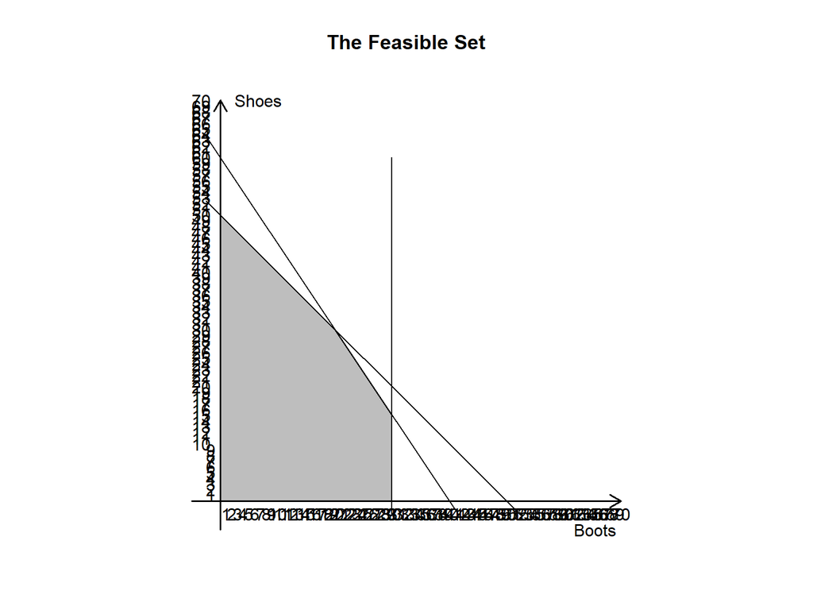

```r
# For two dimmension problems can plot the problem
plot(lp_primal)
```

# View dual solution

```r
# Dual solution
get.dual.solution(lp_primal)
```

```
## [1] 1.00 1.25 0.00 2.50 0.00 0.00
```

- What do the results indicate
  - 1.00 indicates the dual is feasible
  - 1.25, if increase L by 1 unit, profit increase by $1.25
  - 0.00, if increase M by 1 unit, profit increase by $0
  - 2.50, if increase D by 1 unit, profit increase by $2.50
  - 0.00 and 0.00 indicate no “slack” in the variables
- **How can profit increase by $1.25 or $2.50 if boots are $40 and shoes $25?**

# Set up the dual problem so can compare results

- Program the same problem from dual perspective
  - The dual has 3 variables
  - Dual has 2 constraints with inequalities reversed

```r
# Define the model with 0 constraints, is a minimum so not need lp.control()
lp_dual <- make.lp(0, 3)

# Add the constraints
set.objfn(lp_dual, c(1200, 500, 30))
add.constraint(lp_dual, c(30, 10, 1), ">=", 40)
add.constraint(lp_dual, c(20, 10, 0),">=", 25)

dimnames(lp_dual) <- list(c("Boots", "Shoes"),
                            c("Labor", "Machines", "B-demand"))
```

```r
# See the model we have set up
lp_dual
```

```
## Model name:
##              Labor  Machines  B-demand
## Minimize      1200       500        30
## Boots           30        10         1  >=  40
## Shoes           20        10         0  >=  25
## Kind           Std       Std       Std
## Type          Real      Real      Real
## Upper          Inf       Inf       Inf
## Lower            0         0         0
```

# Solve “the dual” model and look at solution

- To be clear
  - This is a code of the dual to the original problem
  - The dual of this is the primal of the model we first set up
  - Mathematcially, it is arbitrary which is the primal and which is the dual
  - Conceptually, set the primal as the model that makes the most sense for the application

```r
# Solve model
solve(lp_dual)
```

```
## [1] 0
```

```r
# Output, gives i) obj, ii) 2 constraints values, and iii) 3 variable values
get.primal.solution(lp_dual)
```

```
## [1] 1575.00   40.00   25.00    1.25    0.00    2.50
```

# Solve “the dual” model and look at solution

```r
# Output, gives i) obj, ii) 2 constraint values and iii) 3 variable values
get.dual.solution(lp_dual)
```

```
## [1]  1 30 15  0 50  0
```

- What do the results indicate
  - 1.00 indicates the dual is feasible
  - 30, if net profit of B increase by 1 dollar, profit increase by $30
  - 15, if net profit of S increase by 1 dollar, profit increase by $15
  - 0, all of L is used
  - 50, M not used
  - 0, all of D is used

# Sensitivity analysis

- Over what variable and constraint ranges will the solution hold?

```r
# Get sensitivity analysis of primal
get.sensitivity.obj(lp_primal)
```

```
## $objfrom
## [1] 37.5  0.0
##
## $objtill
## [1] 1.000000e+30 2.666667e+01
```

```r
get.sensitivity.rhs(lp_primal)
```

```
## $duals
## [1] 1.25 0.00 2.50 0.00 0.00
##
## $dualsfrom
## [1]  9e+02 -1e+30  2e+01 -1e+30 -1e+30
##
## $dualstill
## [1] 1.3e+03 1.0e+30 4.0e+01 1.0e+30 1.0e+30
```

- Hard to tell what output is so will make a table

# Sensitivity analysis table

```r
# Build a table to make understanding the results easier
obj_fn <- c(40, 25)
ps <- get.primal.solution(lp_primal)
obj_sa <- get.sensitivity.obj(lp_primal)
rhs_sa <- get.sensitivity.rhs(lp_primal)

# Table dimmensions
n <- length(get.variables(lp_primal))
m <- length(get.constr.type(lp_primal))

# Make output and table
ov <- paste0("Objective function value = ", ps[1])
sa_tab <- rbind(ps[2:(n + m + 1)],
                c(round(rhs_sa$duals[1:m], 2), obj_fn),
                round(c(rhs_sa$dualsfrom[1:m],obj_sa$objfrom), 2),
                round(c(rhs_sa$dualstill[1:m],obj_sa$objtill), 2))
colnames(sa_tab) <- c(rownames(lp_primal), colnames(lp_primal))
rownames(sa_tab) <- c("Solution", "Duals/Coef", "Sens From", "Sens Till")

# Substitute "inf" and "-inf" so tables are easier to read (coded by two classmates!)
sa_tab <- ifelse(sa_tab == -1.000e+30, "-inf", sa_tab)
sa_tab <- ifelse(sa_tab == 1.000e+30, "inf", sa_tab)
```

```r
# Objective value and sensitivity analysis table
ov
```

```
## [1] "Objective function value = 1575"
```

```r
as.table(sa_tab)
```

```
##            Labor Machines B-demand Boots Shoes
## Solution   1200  450      30       30    15
## Duals/Coef 1.25  0        2.5      40    25
## Sens From  900   -inf     20       37.5  0
## Sens Till  1300  inf      40       inf   26.67
```

# Sensitivity analysis

- We can format the table to be easier to read

```r
# Beautify the table using knitr and kableExtra packages, and add %>%
`%>%` <- magrittr::`%>%`
library(knitr)
library(kableExtra)

# Print the table
kable(sa_tab, format.args = list(big.mark = ",")) %>%
  kable_styling(bootstrap_options = c("striped", "bordered")) %>%
  add_footnote(label = ov, notation = "none")
```

|  | Labor | Machines | B-demand | Boots | Shoes |
| --- | --- | --- | --- | --- | --- |
| Solution | 1200 | 450 | 30 | 30 | 15 |
| Duals/Coef | 1.25 | 0 | 2.5 | 40 | 25 |
| Sens From | 900 | -inf | 20 | 37.5 | 0 |
| Sens Till | 1300 | inf | 40 | inf | 26.67 |

Objective function value = 1575

- What if we add 1 more unit of Boot demand as discussed earlier?

# Sensitivity analysis

|  | Labor | Machines | B-demand | Boots | Shoes |
| --- | --- | --- | --- | --- | --- |
| Solution | 1200 | 445 | 31 | 31 | 13.5 |
| Duals/Coef | 1.25 | 0 | 2.5 | 40 | 25 |
| Sens From | 930 | -inf | 20 | 37.5 | 0 |
| Sens Till | 1310 | inf | 40 | inf | 26.67 |

Objective function value = 1577.5

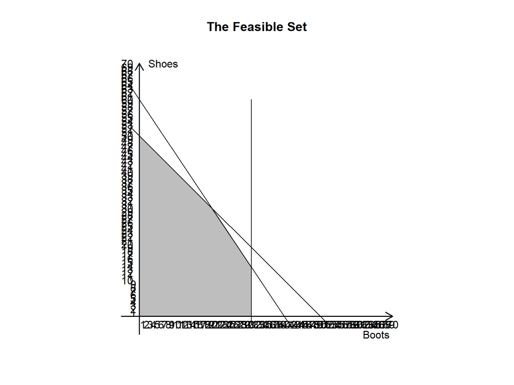

```r
# For two dimmension problems can plot the problem
plot(lp_primal_1)
```